# ROTCTradingVariable

Rolando

2/26/2020

## 文件目的

- 此文檔是為了要整理有關興櫃期間的交易變數，共有五種，包括：
1. Stock Volitility (IPO前三個月股票報酬標準差)
2. Idiosyncratic Volatility (興櫃期間日報酬做出的殘差的標準差 當作是特有風險的波動程度，若數值大，則代表此股票更容易經歷較大的特有風險)
3. The percentage of zero trading days in ROTC (Three months prior IPO)
4. The percentage of zero return days in ROTC (Three months prior IPO)
5. Amihud ratio (IPO前三個月的日報酬 / 每日交易額, 值越大，流動性越差)

## 1. Stock Volitility

- IPO前三個月股票報酬標準差
- 製作 **StockVolitility_ROTC_ToJoin** 用以合併入最終data中
- 8454 富邦媒 原本平均股價約為 256.6514元，但2014/09/09那天股價居然僅有三元，懷疑是資料誤植，因此直接刪除2014/09/09, 2014/10/10的資料。
- 6270 倍微 並沒有抓取到興櫃期間的股價交易資訊，因此先刪除此樣本。
- 最後使用summary去看，以IPOFail來區分並沒有太大差異，以中位數來說，IPOFail的報酬率標準差約為3，而IPOUnFail 約為2.8。

```r
StockVolitility_ROTC_Data <- ROTCDailyTrading_Data %>%
  left_join(., ListFirm %>%
              .[, .SD, .SDcols = c("公司簡稱", "TSE新產業名", "上市櫃日期",  "IPOFail")],
            by = "公司簡稱") %>%
  select("公司簡稱", "TSE新產業名", "IPOFail", "上市櫃日期", everything()) %>%
  setDT() %>%
  .[order(`公司簡稱`, `年月日`)] %>%
  .[!(which(公司簡稱 == "8454 富邦媒" & abs(`報酬率％`) > 90))] %>%
  # 2014/9/9當日股價過於奇怪
  .[, tail(.SD, 90), by = "公司簡稱"]

# 最終data
StockVolitility_ROTC <- StockVolitility_ROTC_Data %>%
  .[, .SD, .SDcols = c(1:5, 12)] %>%
  .[, list(SD_Return90DaysBeforeIPO = sd(`報酬率％`)), by = "公司簡稱"] %>%
  left_join(., ListFirm %>%
              .[, .SD, .SDcols = c("公司簡稱", "TSE新產業名", "上市櫃日期",  "IPOFail")],
            by = "公司簡稱") %>%
  select("公司簡稱", "TSE新產業名", "IPOFail", "上市櫃日期", everything()) %>%
  setDT()

# 顯示出 StockVolitility_ROTC 所有結果，並以滾動捲軸呈現
StockVolitility_ROTC %>%
  select(everything()) %>%
  kable("html", escape = F, align = "l") %>%
  kable_styling("hover", full_width = T) %>%
  scroll_box(width = "800px", height = "500px")
```

| 公司簡稱 | TSE新產業名 | IPOFail | 上市櫃日期 | SD_Return90DaysBeforeIPO |
| --- | --- | --- | --- | --- |
| 1259 安心 | M2700 觀光事業 | 0 | 2011-12-15 | 1.4625229 |
| 1333 恩得利 | M2328 電子零組件 | 0 | 2005-08-08 | 2.8584582 |
| 1336 台翰 | M2328 電子零組件 | 0 | 2007-11-02 | 2.0546644 |
| 1338 廣華-KY | M2200 汽車工業 | 0 | 2012-12-19 | 1.9817749 |
| 1339 昭輝 | M2200 汽車工業 | 0 | 2012-04-24 | 1.9567967 |
| 1558 伸興 | M1500 電機機械 | 0 | 2007-12-28 | 3.1271077 |
| 1560 中砂 | M1500 電機機械 | 0 | 2005-01-31 | 4.6174687 |
| 1565 精華 | M1722 生技醫療 | 0 | 2004-03-30 | 5.7807774 |
| 1566 捷邦 | M1500 電機機械 | 0 | 2011-01-12 | 4.5720262 |
| 1568 倉佑 | M2200 汽車工業 | 0 | 2014-05-14 | 2.4063285 |
| 1569 濱川 | M2325 電腦及週邊 | 0 | 2005-07-29 | 4.2607269 |
| 1570 力肯 | M1500 電機機械 | 0 | 2005-06-30 | 1.6115638 |
| 1580 新麥 | M1500 電機機械 | 0 | 2007-12-10 | 2.5724550 |
| 1582 信錦 | M2328 電子零組件 | 0 | 2007-01-11 | 2.9358945 |
| 1583 程泰 | M1500 電機機械 | 0 | 2008-01-24 | 2.3153576 |
| 1584 精剛 | M9900 其他 | 0 | 2007-11-28 | 3.1240056 |
| 1586 和勤 | M1500 電機機械 | 0 | 2012-01-09 | 2.2847209 |
| 1591 駿吉-KY | M1500 電機機械 | 0 | 2012-03-23 | 1.8214755 |
| 1593 祺驊 | M1722 生技醫療 | 0 | 2012-06-13 | 2.1470449 |
| 1595 川寶 | M2328 電子零組件 | 0 | 2011-10-04 | 1.9606712 |
| 1597 直得 | M1500 電機機械 | 0 | 2012-12-28 | 5.1154974 |
| 1599 宏佳騰 | M1500 電機機械 | 0 | 2012-12-25 | 2.1701344 |
| 1742 台蠟 | M1721 化學工業 | 0 | 2004-05-14 | 3.5542863 |
| 1752 南光 | M1722 生技醫療 | 0 | 2009-08-10 | 5.3209295 |
| 1762 中化生 | M1722 生技醫療 | 0 | 2010-12-20 | 2.0025005 |
| 1773 勝一 | M1721 化學工業 | 0 | 2009-02-27 | 5.7352536 |
| 1777 生泰 | M1722 生技醫療 | 0 | 2005-10-19 | 1.9520442 |
| 1781 合世 | M1722 生技醫療 | 0 | 2004-12-24 | 2.9724399 |
| 1783 和康生 | M1722 生技醫療 | 0 | 2013-12-20 | 2.6000839 |
| 1784 訊聯 | M1722 生技醫療 | 0 | 2007-07-26 | 6.9228180 |

[output cut: 629 more lines]

```r
# Data to join
StockVolitility_ROTC_ToJoin <- StockVolitility_ROTC %>%
  .[, .SD, .SDcols = c("公司簡稱", "SD_Return90DaysBeforeIPO")]

StockVolitility_ROTC %>%
  .[!(`公司簡稱` == "6270 倍微")] %>%
  GetSummaryGroupByIPOFailAndTotal(., "SD_Return90DaysBeforeIPO") %>%
  kable(., caption = "以IPO失敗與否區分之StockVolitility", align = "l") %>%
  kable_styling(full_width = TRUE)
```

以IPO失敗與否區分之StockVolitility

| SD_Return90DaysBeforeIPO | n | mean | median | min | max | range | skew | kurtosis |
| --- | --- | --- | --- | --- | --- | --- | --- | --- |
| Total | 658 | 3.130355 | 2.839167 | 0.5428593 | 10.574908 | 10.032048 | 1.540458 | 4.022046 |
| IPO_NoFail | 598 | 3.115700 | 2.807434 | 0.5428593 | 10.574908 | 10.032048 | 1.580262 | 4.237444 |
| IPO_Fail | 60 | 3.276408 | 3.032820 | 1.1611607 | 7.728585 | 6.567424 | 1.125700 | 1.768453 |

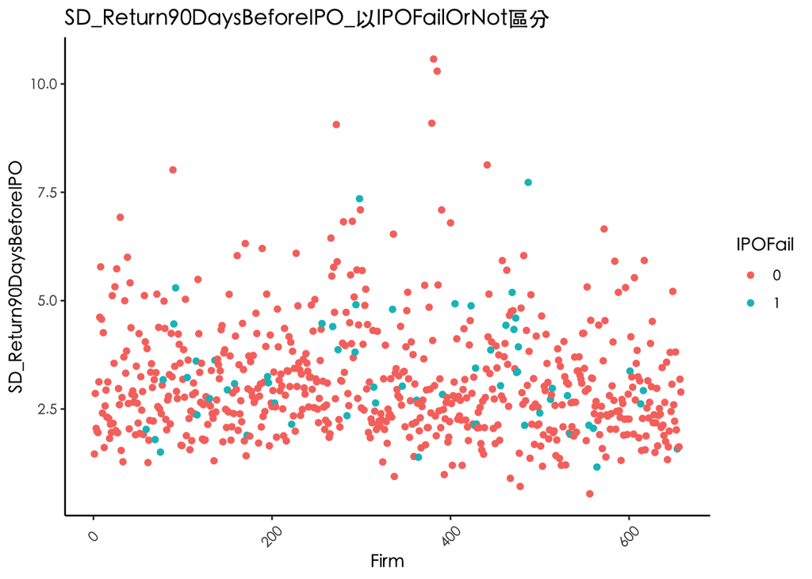

```r
StockVolitility_ROTC %>%
  .[!(`公司簡稱` == "6270 倍微")] %>%
  GeomPoint_IPOFailOrNot(.,  "SD_Return90DaysBeforeIPO")
```

- 以上市(櫃)後250天的資料計算股票報酬率波動度。
- 製作 **StockVolitility_AfterIPO_ToJoin** 用以合併入最終data中
- Summary 的結果來看，IPOFail 公司平均來說會有比較低的波動度(3.3 vs 3.7)，但以中位數來說沒有太大差別。

```r
StockVolitility_AfterIPO_Data <- AllFirm_Trading02_16 %>%
  left_join(., ListFirm %>%
              .[, .SD, .SDcols = c("公司簡稱", "TSE新產業名", "上市櫃日期",  "IPOFail")],
            by = "公司簡稱") %>%
  setDT() %>%
  .[`年月日` >= `上市櫃日期`] %>%
  .[, head(.SD, 250), by = "公司簡稱"]

# 最終data
StockVolitility_AfterIPO <- StockVolitility_AfterIPO_Data %>%
  .[, .SD, .SDcols = c(1, 8, 10, 9, 2, 4)] %>%
  .[, list(SD_Return250DaysAfterIPO = sd(`報酬率％`)), by = "公司簡稱"] %>%
  left_join(., ListFirm %>%
              .[, .SD, .SDcols = c("公司簡稱", "TSE新產業名", "上市櫃日期",  "IPOFail")],
            by = "公司簡稱") %>%
  select("公司簡稱", "TSE新產業名", "IPOFail", "上市櫃日期", everything()) %>%
  setDT()

# 顯示出 StockVolitility_AfterIPO 所有結果，並以滾動捲軸呈現
StockVolitility_AfterIPO %>%
  select(everything()) %>%
  kable("html", escape = F, align = "l") %>%
  kable_styling("hover", full_width = T) %>%
  scroll_box(width = "800px", height = "500px")
```

| 公司簡稱 | TSE新產業名 | IPOFail | 上市櫃日期 | SD_Return250DaysAfterIPO |
| --- | --- | --- | --- | --- |
| 1259 安心 | M2700 觀光事業 | 0 | 2011-12-15 | 1.896438 |
| 1333 恩得利 | M2328 電子零組件 | 0 | 2005-08-08 | 3.574007 |
| 1336 台翰 | M2328 電子零組件 | 0 | 2007-11-02 | 3.356853 |
| 1338 廣華-KY | M2200 汽車工業 | 0 | 2012-12-19 | 1.725089 |
| 1339 昭輝 | M2200 汽車工業 | 0 | 2012-04-24 | 1.406744 |
| 1558 伸興 | M1500 電機機械 | 0 | 2007-12-28 | 2.481280 |
| 1560 中砂 | M1500 電機機械 | 0 | 2005-01-31 | 2.459567 |
| 1565 精華 | M1722 生技醫療 | 0 | 2004-03-30 | 2.444071 |
| 1566 捷邦 | M1500 電機機械 | 0 | 2011-01-12 | 4.590671 |
| 1568 倉佑 | M2200 汽車工業 | 0 | 2014-05-14 | 2.599332 |
| 1569 濱川 | M2325 電腦及週邊 | 0 | 2005-07-29 | 2.458468 |
| 1570 力肯 | M1500 電機機械 | 0 | 2005-06-30 | 2.121974 |
| 1580 新麥 | M1500 電機機械 | 0 | 2007-12-10 | 2.246574 |
| 1582 信錦 | M2328 電子零組件 | 0 | 2007-01-11 | 3.717492 |
| 1583 程泰 | M1500 電機機械 | 0 | 2008-01-24 | 2.542792 |
| 1584 精剛 | M9900 其他 | 0 | 2007-11-28 | 2.792237 |
| 1586 和勤 | M1500 電機機械 | 0 | 2012-01-09 | 2.429558 |
| 1591 駿吉-KY | M1500 電機機械 | 0 | 2012-03-23 | 3.293477 |
| 1593 祺驊 | M1722 生技醫療 | 0 | 2012-06-13 | 2.340453 |
| 1595 川寶 | M2328 電子零組件 | 0 | 2011-10-04 | 2.620191 |
| 1597 直得 | M1500 電機機械 | 0 | 2012-12-28 | 3.209434 |
| 1599 宏佳騰 | M1500 電機機械 | 0 | 2012-12-25 | 1.814697 |
| 1742 台蠟 | M1721 化學工業 | 0 | 2004-05-14 | 1.754065 |
| 1752 南光 | M1722 生技醫療 | 0 | 2009-08-10 | 6.185977 |
| 1762 中化生 | M1722 生技醫療 | 0 | 2010-12-20 | 2.808872 |
| 1773 勝一 | M1721 化學工業 | 0 | 2009-02-27 | 2.894715 |
| 1777 生泰 | M1722 生技醫療 | 0 | 2005-10-19 | 1.918540 |
| 1781 合世 | M1722 生技醫療 | 0 | 2004-12-24 | 3.335771 |
| 1783 和康生 | M1722 生技醫療 | 0 | 2013-12-20 | 3.536147 |
| 1784 訊聯 | M1722 生技醫療 | 0 | 2007-07-26 | 46.095858 |

[output cut: 629 more lines]

```r
# Data to join
StockVolitility_AfterIPO_ToJoin <- StockVolitility_AfterIPO %>%
  .[, .SD, .SDcols = c("公司簡稱", "SD_Return250DaysAfterIPO")]

StockVolitility_AfterIPO %>%
  GetSummaryGroupByIPOFailAndTotal(., "SD_Return250DaysAfterIPO") %>%
  kable(., caption = "以IPO失敗與否區分之StockVolitility", align = "l") %>%
  kable_styling(full_width = TRUE)
```

以IPO失敗與否區分之StockVolitility

| SD_Return250DaysAfterIPO | n | mean | median | min | max | range | skew | kurtosis |
| --- | --- | --- | --- | --- | --- | --- | --- | --- |
| Total | 659 | 3.712439 | 3.073505 | 1.284114 | 46.095858 | 44.811744 | 7.893800 | 99.89409 |
| IPO_NoFail | 599 | 3.746534 | 3.052775 | 1.284114 | 46.095858 | 44.811744 | 7.650757 | 92.89726 |
| IPO_Fail | 60 | 3.372061 | 3.193857 | 1.674330 | 7.322201 | 5.647871 | 1.937222 | 5.07013 |

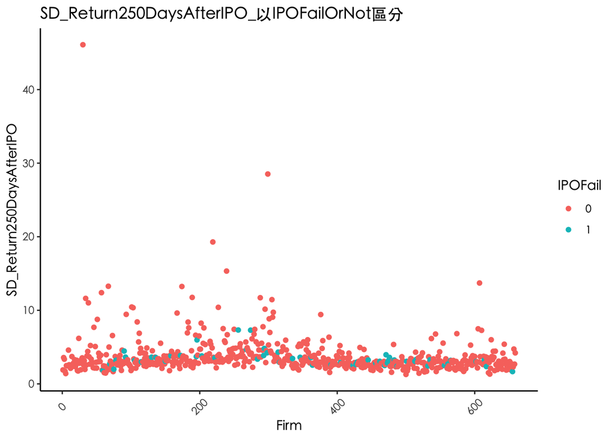

```r
StockVolitility_AfterIPO %>%
  GeomPoint_IPOFailOrNot(.,  "SD_Return250DaysAfterIPO")
```

## 2. Idiosyncratic Volatility

- 興櫃期間日報酬做出的殘差的標準差當作是特有風險的波動程度，若數值大，則代表此股票更容易經歷較大的特有風險。
- 最後製作出 **IdiosyncraticVolatility_ToJoin** 用以合併入最終data中。
- 以Summary 的結果來看 IPOFail 的確會有比較高一點的殘差標準差，但差距並不大。(Mean: 3.2 v.s 3.0)

```r
# 計算所有公司的Market Model 殘差
MarketReturn_Data_ToJoin <- MarketReturn_Data %>%
  setnames(., c("證券代碼", "報酬率(%)"), c("Market", "MarketReturn(%)")) %>%
  .[, Market := case_when(
    Market == "OTC99 OTC 指數" ~ "OTC",
    Market == "Y9999 加權指數" ~ "TSE"
  )] %>%
  .[, -c(3)]

IdiosyncraticVolatilityData_ToJoin <- ROTCDailyTrading_Data %>%
  left_join(., ListFirm %>%
              .[, .SD, .SDcols = c("公司簡稱", "TSE新產業名", "Market", "上市櫃日期",  "IPOFail")],
            by = "公司簡稱") %>%
  select("公司簡稱", "TSE新產業名", "IPOFail", "上市櫃日期", everything()) %>%
  setDT() %>%
  .[order(`公司簡稱`, `年月日`)] %>%
  .[!(which(公司簡稱 == "8454 富邦媒" & abs(`報酬率％`) > 90))] %>%
  # 2014/9/9當日股價過於奇怪
  .[, tail(.SD, 90), by = "公司簡稱"] %>%
  .[, .SD, .SDcols = c("公司簡稱", "Market", "TSE新產業名", "上市櫃日期", "IPOFail", "年月日", "報酬率％")]

# 要丟入市場模型中的最終data
IdiosyncraticVolatilityData <- IdiosyncraticVolatilityData_ToJoin %>%
  left_join(., MarketReturn_Data_ToJoin, by = c("年月日", "Market")) %>%
  setDT() %>%
  .[, `:=` (AbnormalFirmReturn = `報酬率％` - 無風險利率,
            AbnormalMarketReturn = `MarketReturn(%)` - 無風險利率)]

GetMarketModelResiduals <- function(Data, Firm){

  CompanyData <- Data %>%
    .[`公司簡稱` == Firm]

  MarketModel <- lm(`AbnormalFirmReturn` ~ `AbnormalMarketReturn`, data = CompanyData)

  SDResidual <- sd(MarketModel$residuals)

  return(SDResidual)
}

# test the GetMarketModelResiduals
# GetMarketModelResiduals(IdiosyncraticVolatilityData, ListFirm$公司簡稱[3])

# Final Data for IdiosyncraticVolatility
IdiosyncraticVolatility <- ListFirm %>%
  .[, .SD, .SDcols = c(1, 2, 5, 11, 15)] %>%
  .[, SD_MarketModelResidual:= sapply(`公司簡稱`,
       function(x) GetMarketModelResiduals(IdiosyncraticVolatilityData, x))]

# 顯示出 IdiosyncraticVolatility 所有結果，並以滾動捲軸呈現
IdiosyncraticVolatility %>%
  select(everything()) %>%
  kable("html", escape = F, align = "l") %>%
  kable_styling("hover", full_width = T) %>%
  scroll_box(width = "800px", height = "500px")
```

| 公司簡稱 | TSE新產業名 | 上市櫃日期 | Market | IPOFail | SD_MarketModelResidual |
| --- | --- | --- | --- | --- | --- |
| 1259 安心 | M2700 觀光事業 | 2011-12-15 | OTC | 0 | 1.3953983 |
| 1333 恩得利 | M2328 電子零組件 | 2005-08-08 | OTC | 0 | 2.8313466 |
| 1336 台翰 | M2328 電子零組件 | 2007-11-02 | OTC | 0 | 2.0172095 |
| 1338 廣華-KY | M2200 汽車工業 | 2012-12-19 | TSE | 0 | 1.9793843 |
| 1339 昭輝 | M2200 汽車工業 | 2012-04-24 | TSE | 0 | 1.9517933 |
| 1558 伸興 | M1500 電機機械 | 2007-12-28 | OTC | 0 | 3.1024329 |
| 1560 中砂 | M1500 電機機械 | 2005-01-31 | TSE | 0 | 4.5772321 |
| 1565 精華 | M1722 生技醫療 | 2004-03-30 | OTC | 0 | 5.7759776 |
| 1566 捷邦 | M1500 電機機械 | 2011-01-12 | OTC | 0 | 4.5717054 |
| 1568 倉佑 | M2200 汽車工業 | 2014-05-14 | TSE | 0 | 2.3614082 |
| 1569 濱川 | M2325 電腦及週邊 | 2005-07-29 | OTC | 0 | 4.2457834 |
| 1570 力肯 | M1500 電機機械 | 2005-06-30 | OTC | 0 | 1.5886420 |
| 1580 新麥 | M1500 電機機械 | 2007-12-10 | OTC | 0 | 2.5426206 |
| 1582 信錦 | M2328 電子零組件 | 2007-01-11 | OTC | 0 | 2.9287475 |
| 1583 程泰 | M1500 電機機械 | 2008-01-24 | TSE | 0 | 2.3150295 |
| 1584 精剛 | M9900 其他 | 2007-11-28 | OTC | 0 | 2.8823057 |
| 1586 和勤 | M1500 電機機械 | 2012-01-09 | OTC | 0 | 2.2161260 |
| 1591 駿吉-KY | M1500 電機機械 | 2012-03-23 | OTC | 0 | 1.8049629 |
| 1593 祺驊 | M1722 生技醫療 | 2012-06-13 | OTC | 0 | 2.1255395 |
| 1595 川寶 | M2328 電子零組件 | 2011-10-04 | OTC | 0 | 1.7567046 |
| 1597 直得 | M1500 電機機械 | 2012-12-28 | OTC | 0 | 5.0935850 |
| 1599 宏佳騰 | M1500 電機機械 | 2012-12-25 | OTC | 0 | 2.1509921 |
| 1742 台蠟 | M1721 化學工業 | 2004-05-14 | OTC | 0 | 3.5537619 |
| 1752 南光 | M1722 生技醫療 | 2009-08-10 | OTC | 0 | 5.2471793 |
| 1762 中化生 | M1722 生技醫療 | 2010-12-20 | TSE | 0 | 1.9237021 |
| 1773 勝一 | M1721 化學工業 | 2009-02-27 | TSE | 0 | 5.7894292 |
| 1777 生泰 | M1722 生技醫療 | 2005-10-19 | OTC | 0 | 1.9483508 |
| 1781 合世 | M1722 生技醫療 | 2004-12-24 | OTC | 0 | 2.9580028 |
| 1783 和康生 | M1722 生技醫療 | 2013-12-20 | TSE | 0 | 2.5440310 |
| 1784 訊聯 | M1722 生技醫療 | 2007-07-26 | OTC | 0 | 6.8089182 |

[output cut: 629 more lines]

```r
# Data to join
IdiosyncraticVolatility_ToJoin <- IdiosyncraticVolatility %>%
  .[, .SD, .SDcols = c("公司簡稱", "SD_MarketModelResidual")]


# Summary of IdiosyncraticVolatility
IdiosyncraticVolatility %>%
  .[!(`公司簡稱` == "6270 倍微")] %>%
  GetSummaryGroupByIPOFailAndTotal(., "SD_MarketModelResidual") %>%
  kable(., caption = "以IPO失敗與否區分之IdiosyncraticVolatility ", align = "l") %>%
  kable_styling(full_width = TRUE)
```

以IPO失敗與否區分之IdiosyncraticVolatility

| SD_MarketModelResidual | n | mean | median | min | max | range | skew | kurtosis |
| --- | --- | --- | --- | --- | --- | --- | --- | --- |
| Total | 658 | 3.064342 | 2.770149 | 0.5403004 | 10.565661 | 10.025361 | 1.591849 | 4.402375 |
| IPO_NoFail | 598 | 3.049584 | 2.742949 | 0.5403004 | 10.565661 | 10.025361 | 1.636759 | 4.659943 |
| IPO_Fail | 60 | 3.211430 | 2.980556 | 1.1420734 | 7.626055 | 6.483982 | 1.126637 | 1.753631 |

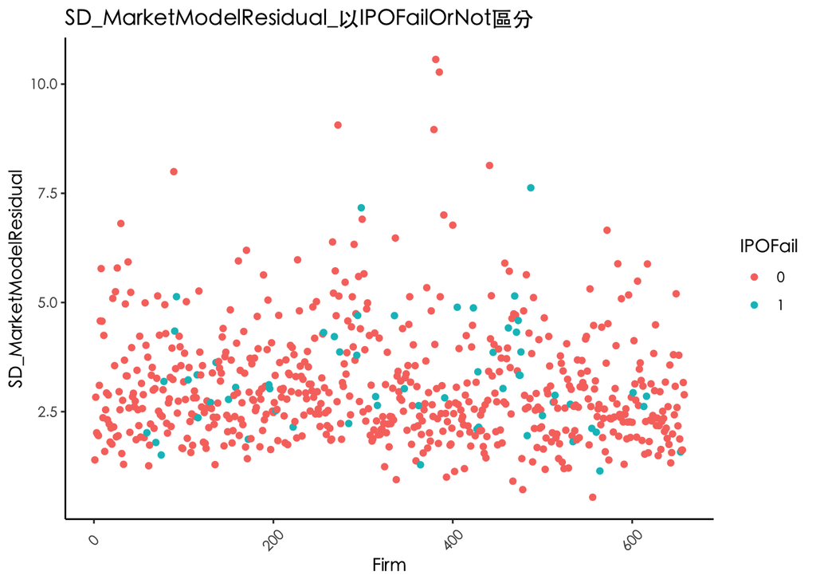

```r
IdiosyncraticVolatility %>%
  .[!(`公司簡稱` == "6270 倍微")] %>%
  GeomPoint_IPOFailOrNot(.,  "SD_MarketModelResidual")
```

- 公司IPO後一年之交易資料，以四因子模型取出殘差的標準差當作是特有風險的波動程度，若數值大，則代表此股票更容易經歷較大的特有風險。
- 最後製作出 **IdiosyncraticVolatility_AfterIPO_ToJoin** 用以合併入最終data中。
- 以Summary 的結果來看 IPOFail 平均來說會有比較低一點的殘差標準差。(IPOFail Mean: 3.1 v.s UnFail 3.4 )，但從中位數來看 卻是 UnFail略低。

```r
IdiosyncraticVolatility_AfterIPO_Data <- AllFirm_Trading02_16 %>%
  left_join(., ListFirm %>%
              .[, .SD, .SDcols = c("公司簡稱", "TSE新產業名", "上市櫃日期",  "IPOFail")],
            by = "公司簡稱") %>%
  setDT() %>%
  .[`年月日` >= `上市櫃日期`] %>%
  .[, head(.SD, 250), by = "公司簡稱"] %>%
  left_join(., FourFactorsVariables_Data, by = "年月日") %>%
  setDT() %>%
  .[, .SD, .SDcols = c("公司簡稱", "TSE新產業名", "上市櫃日期", "IPOFail",
                       "年月日", "報酬率％", "市場風險溢酬", "規模溢酬(3因子)",
                       "淨值市價比溢酬", "動能因子")]

GetMarketModelResiduals <- function(Data, Firm){

  CompanyData <- Data %>%
    .[`公司簡稱` == Firm]

  MarketModel <- lm(`報酬率％` ~
                      `市場風險溢酬`+ `規模溢酬(3因子)`+ `淨值市價比溢酬`+ `動能因子`,
                    data = CompanyData)

  SDResidual <- sd(MarketModel$residuals)

  return(SDResidual)

}

# test the GetMarketModelResiduals
# GetMarketModelResiduals(IdiosyncraticVolatility_AfterIPO_Data, ListFirm$公司簡稱[3])

# Final Data for IdiosyncraticVolatility
IdiosyncraticVolatility_AfterIPO <- ListFirm %>%
  .[, .SD, .SDcols = c(1, 2, 5, 11, 15)] %>%
  .[, SD_MarketModelResidual:= sapply(`公司簡稱`,
       function(x) GetMarketModelResiduals(IdiosyncraticVolatility_AfterIPO_Data, x))]

# 顯示出 IdiosyncraticVolatility 所有結果，並以滾動捲軸呈現
IdiosyncraticVolatility_AfterIPO %>%
  select(everything()) %>%
  kable("html", escape = F, align = "l") %>%
  kable_styling("hover", full_width = T) %>%
  scroll_box(width = "800px", height = "500px")
```

| 公司簡稱 | TSE新產業名 | 上市櫃日期 | Market | IPOFail | SD_MarketModelResidual |
| --- | --- | --- | --- | --- | --- |
| 1259 安心 | M2700 觀光事業 | 2011-12-15 | OTC | 0 | 1.570411 |
| 1333 恩得利 | M2328 電子零組件 | 2005-08-08 | OTC | 0 | 3.268529 |
| 1336 台翰 | M2328 電子零組件 | 2007-11-02 | OTC | 0 | 2.881785 |
| 1338 廣華-KY | M2200 汽車工業 | 2012-12-19 | TSE | 0 | 1.686551 |
| 1339 昭輝 | M2200 汽車工業 | 2012-04-24 | TSE | 0 | 1.334013 |
| 1558 伸興 | M1500 電機機械 | 2007-12-28 | OTC | 0 | 2.397685 |
| 1560 中砂 | M1500 電機機械 | 2005-01-31 | TSE | 0 | 2.245496 |
| 1565 精華 | M1722 生技醫療 | 2004-03-30 | OTC | 0 | 2.270357 |
| 1566 捷邦 | M1500 電機機械 | 2011-01-12 | OTC | 0 | 4.267596 |
| 1568 倉佑 | M2200 汽車工業 | 2014-05-14 | TSE | 0 | 2.423064 |
| 1569 濱川 | M2325 電腦及週邊 | 2005-07-29 | OTC | 0 | 2.345972 |
| 1570 力肯 | M1500 電機機械 | 2005-06-30 | OTC | 0 | 2.014606 |
| 1580 新麥 | M1500 電機機械 | 2007-12-10 | OTC | 0 | 2.058786 |
| 1582 信錦 | M2328 電子零組件 | 2007-01-11 | OTC | 0 | 3.495249 |
| 1583 程泰 | M1500 電機機械 | 2008-01-24 | TSE | 0 | 2.003026 |
| 1584 精剛 | M9900 其他 | 2007-11-28 | OTC | 0 | 2.444574 |
| 1586 和勤 | M1500 電機機械 | 2012-01-09 | OTC | 0 | 2.243474 |
| 1591 駿吉-KY | M1500 電機機械 | 2012-03-23 | OTC | 0 | 3.180221 |
| 1593 祺驊 | M1722 生技醫療 | 2012-06-13 | OTC | 0 | 2.185223 |
| 1595 川寶 | M2328 電子零組件 | 2011-10-04 | OTC | 0 | 2.102630 |
| 1597 直得 | M1500 電機機械 | 2012-12-28 | OTC | 0 | 3.069732 |
| 1599 宏佳騰 | M1500 電機機械 | 2012-12-25 | OTC | 0 | 1.766179 |
| 1742 台蠟 | M1721 化學工業 | 2004-05-14 | OTC | 0 | 1.686341 |
| 1752 南光 | M1722 生技醫療 | 2009-08-10 | OTC | 0 | 5.984117 |
| 1762 中化生 | M1722 生技醫療 | 2010-12-20 | TSE | 0 | 2.393137 |
| 1773 勝一 | M1721 化學工業 | 2009-02-27 | TSE | 0 | 2.475242 |
| 1777 生泰 | M1722 生技醫療 | 2005-10-19 | OTC | 0 | 1.885593 |
| 1781 合世 | M1722 生技醫療 | 2004-12-24 | OTC | 0 | 3.164240 |
| 1783 和康生 | M1722 生技醫療 | 2013-12-20 | TSE | 0 | 3.219072 |
| 1784 訊聯 | M1722 生技醫療 | 2007-07-26 | OTC | 0 | 45.998352 |

[output cut: 629 more lines]

```r
# Data to join
IdiosyncraticVolatility_AfterIPO_ToJoin <- IdiosyncraticVolatility_AfterIPO %>%
  .[, .SD, .SDcols = c("公司簡稱", "SD_MarketModelResidual")]


# Summary of IdiosyncraticVolatility
IdiosyncraticVolatility_AfterIPO %>%
  #.[!(`公司簡稱` == "6270 倍微")] %>%
  GetSummaryGroupByIPOFailAndTotal(., "SD_MarketModelResidual") %>%
  kable(., caption = "以IPO失敗與否區分之IdiosyncraticVolatility ", align = "l") %>%
  kable_styling(full_width = TRUE)
```

以IPO失敗與否區分之IdiosyncraticVolatility

| SD_MarketModelResidual | n | mean | median | min | max | range | skew | kurtosis |
| --- | --- | --- | --- | --- | --- | --- | --- | --- |
| Total | 659 | 3.430170 | 2.779964 | 1.195848 | 45.998352 | 44.802504 | 8.024690 | 102.189175 |
| IPO_NoFail | 599 | 3.462607 | 2.758321 | 1.195848 | 45.998352 | 44.802504 | 7.759873 | 94.704436 |
| IPO_Fail | 60 | 3.106346 | 2.861609 | 1.577878 | 6.691757 | 5.113878 | 1.895244 | 4.601079 |

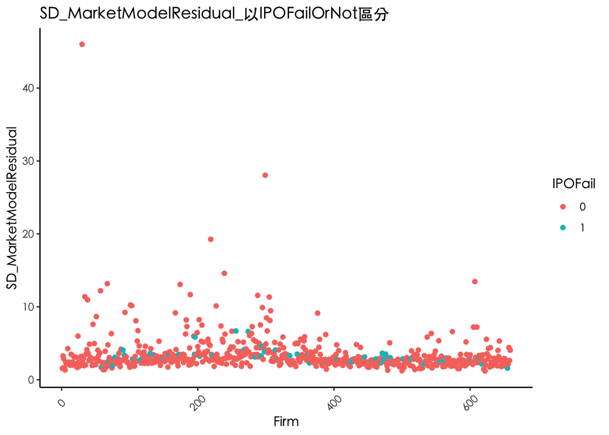

```r
IdiosyncraticVolatility_AfterIPO %>%
  #.[!(`公司簡稱` == "6270 倍微")] %>%
  GeomPoint_IPOFailOrNot(.,  "SD_MarketModelResidual")
```

## 3. Zero Trading Days

- The percentage of zero trading days in ROTC (Three months prior IPO)
- 將**ZeroTradingDays_ToJoin** 用於合併入最終data中。
- 以Summary 結果來看，IPOFail的公司的確會有較高的Zero Trading Ratio (28.46% v.s. 23.39%)

```r
ZeroTradingDays_Data <- ROTCDailyTrading_Data %>%
  left_join(., ListFirm %>%
              .[, .SD, .SDcols = c("公司簡稱", "TSE新產業名", "上市櫃日期",  "IPOFail")],
            by = "公司簡稱") %>%
  select("公司簡稱", "TSE新產業名", "IPOFail", "上市櫃日期", everything()) %>%
  setDT() %>%
  .[order(`公司簡稱`, `年月日`)] %>%
  .[!(which(公司簡稱 == "8454 富邦媒" & abs(`報酬率％`) > 90))] %>%
  # 2014/9/9當日股價過於奇怪
  .[, tail(.SD, 90), by = "公司簡稱"]

ZeroTradingDays <- ZeroTradingDays_Data %>%
  .[, .SD, .SDcols = c("公司簡稱", "TSE新產業名",
                       "IPOFail", "上市櫃日期", "年月日", "成交量(千股)")] %>%
  .[, TradingDays := .N, by = "公司簡稱"] %>%
  .[, ZeroTradingDays := ifelse(`成交量(千股)` ==0, 1, 0) %>% sum, , by = "公司簡稱"] %>%
  .[, ZeroTradingDaysRatio := (ZeroTradingDays / TradingDays)*100] %>%
  .[, tail(.SD, 1), by = "公司簡稱"]

# 顯示出 ZeroTradingDays 所有結果，並以滾動捲軸呈現
ZeroTradingDays %>%
  select(everything()) %>%
  kable("html", escape = F, align = "l") %>%
  kable_styling("hover", full_width = T) %>%
  scroll_box(width = "800px", height = "500px")
```

| 公司簡稱 | TSE新產業名 | IPOFail | 上市櫃日期 | 年月日 | 成交量(千股) | TradingDays | ZeroTradingDays | ZeroTradingDaysRatio |
| --- | --- | --- | --- | --- | --- | --- | --- | --- |
| 1259 安心 | M2700 觀光事業 | 0 | 2011-12-15 | 2011-12-14 | 21 | 90 | 0 | 0.000000 |
| 1333 恩得利 | M2328 電子零組件 | 0 | 2005-08-08 | 2005-08-04 | 1630 | 90 | 11 | 12.222222 |
| 1336 台翰 | M2328 電子零組件 | 0 | 2007-11-02 | 2007-11-01 | 372 | 90 | 1 | 1.111111 |
| 1338 廣華-KY | M2200 汽車工業 | 0 | 2012-12-19 | 2012-12-18 | 197 | 90 | 13 | 14.444444 |
| 1339 昭輝 | M2200 汽車工業 | 0 | 2012-04-24 | 2012-04-23 | 162 | 90 | 20 | 22.222222 |
| 1558 伸興 | M1500 電機機械 | 0 | 2007-12-28 | 2007-12-27 | 124 | 90 | 49 | 54.444444 |
| 1560 中砂 | M1500 電機機械 | 0 | 2005-01-31 | 2005-01-28 | 1273 | 90 | 14 | 15.555556 |
| 1565 精華 | M1722 生技醫療 | 0 | 2004-03-30 | 2004-03-29 | 70 | 90 | 49 | 54.444444 |
| 1566 捷邦 | M1500 電機機械 | 0 | 2011-01-12 | 2011-01-11 | 90 | 90 | 11 | 12.222222 |
| 1568 倉佑 | M2200 汽車工業 | 0 | 2014-05-14 | 2014-05-13 | 1968 | 90 | 0 | 0.000000 |
| 1569 濱川 | M2325 電腦及週邊 | 0 | 2005-07-29 | 2005-07-28 | 517 | 90 | 53 | 58.888889 |
| 1570 力肯 | M1500 電機機械 | 0 | 2005-06-30 | 2005-06-29 | 96 | 90 | 4 | 4.444444 |
| 1580 新麥 | M1500 電機機械 | 0 | 2007-12-10 | 2007-12-07 | 2 | 90 | 30 | 33.333333 |
| 1582 信錦 | M2328 電子零組件 | 0 | 2007-01-11 | 2007-01-10 | 174 | 90 | 2 | 2.222222 |
| 1583 程泰 | M1500 電機機械 | 0 | 2008-01-24 | 2008-01-23 | 117 | 90 | 3 | 3.333333 |
| 1584 精剛 | M9900 其他 | 0 | 2007-11-28 | 2007-11-27 | 26 | 90 | 0 | 0.000000 |
| 1586 和勤 | M1500 電機機械 | 0 | 2012-01-09 | 2012-01-06 | 48 | 90 | 24 | 26.666667 |
| 1591 駿吉-KY | M1500 電機機械 | 0 | 2012-03-23 | 2012-03-22 | 58 | 90 | 36 | 40.000000 |
| 1593 祺驊 | M1722 生技醫療 | 0 | 2012-06-13 | 2012-06-12 | 19 | 90 | 34 | 37.777778 |
| 1595 川寶 | M2328 電子零組件 | 0 | 2011-10-04 | 2011-10-03 | 100 | 90 | 11 | 12.222222 |
| 1597 直得 | M1500 電機機械 | 0 | 2012-12-28 | 2012-12-27 | 163 | 90 | 0 | 0.000000 |
| 1599 宏佳騰 | M1500 電機機械 | 0 | 2012-12-25 | 2012-12-24 | 43 | 90 | 35 | 38.888889 |
| 1742 台蠟 | M1721 化學工業 | 0 | 2004-05-14 | 2004-05-13 | 0 | 90 | 55 | 61.111111 |
| 1752 南光 | M1722 生技醫療 | 0 | 2009-08-10 | 2009-08-06 | 193 | 90 | 2 | 2.222222 |
| 1762 中化生 | M1722 生技醫療 | 0 | 2010-12-20 | 2010-12-17 | 376 | 90 | 0 | 0.000000 |
| 1773 勝一 | M1721 化學工業 | 0 | 2009-02-27 | 2009-02-26 | 1117 | 90 | 31 | 34.444444 |
| 1777 生泰 | M1722 生技醫療 | 0 | 2005-10-19 | 2005-10-18 | 5 | 90 | 65 | 72.222222 |
| 1781 合世 | M1722 生技醫療 | 0 | 2004-12-24 | 2004-12-23 | 122 | 90 | 62 | 68.888889 |
| 1783 和康生 | M1722 生技醫療 | 0 | 2013-12-20 | 2013-12-19 | 1627 | 90 | 0 | 0.000000 |
| 1784 訊聯 | M1722 生技醫療 | 0 | 2007-07-26 | 2007-07-25 | 656 | 90 | 6 | 6.666667 |

[output cut: 629 more lines]

```r
# Data to join
ZeroTradingDays_ToJoin <- ZeroTradingDays %>%
  .[, .SD, .SDcols = c("公司簡稱", "ZeroTradingDaysRatio")]

# 以Summary 的結果去看
ZeroTradingDays %>%
  GetSummaryGroupByIPOFailAndTotal(., "ZeroTradingDaysRatio") %>%
  kable(., caption = "以IPO失敗與否區分之ZeroTradingDaysRatio", align = "l") %>%
  kable_styling(full_width = TRUE)
```

以IPO失敗與否區分之ZeroTradingDaysRatio

| ZeroTradingDaysRatio | n | mean | median | min | max | range | skew | kurtosis |
| --- | --- | --- | --- | --- | --- | --- | --- | --- |
| Total | 659 | 23.85289 | 12.22222 | 0 | 100.00000 | 100.00000 | 0.9361188 | -0.4075551 |
| IPO_NoFail | 599 | 23.39111 | 11.11111 | 0 | 100.00000 | 100.00000 | 0.9627128 | -0.3511941 |
| IPO_Fail | 60 | 28.46296 | 20.00000 | 0 | 91.11111 | 91.11111 | 0.6633735 | -0.9319994 |

## 4. Zero Return Days

- The percentage of zero return days in ROTC (Three months prior IPO)
- 將**ZeroReturnDays_ToJoin** 用於合併入最終data中。
- 以Summary 結果來看，IPOFail的公司的確會有較高的Zero Return Ratio (35.87% v.s. 32.71%) 尤以中位數來看更加明顯(32.22 v.s. 24.44)

```r
ZeroReturnDays_Data <- ROTCDailyTrading_Data %>%
  left_join(., ListFirm %>%
              .[, .SD, .SDcols = c("公司簡稱", "TSE新產業名", "上市櫃日期",  "IPOFail")],
            by = "公司簡稱") %>%
  select("公司簡稱", "TSE新產業名", "IPOFail", "上市櫃日期", everything()) %>%
  setDT() %>%
  .[order(`公司簡稱`, `年月日`)] %>%
  .[!(which(公司簡稱 == "8454 富邦媒" & abs(`報酬率％`) > 90))] %>%
  # 2014/9/9當日股價過於奇怪
  .[, tail(.SD, 90), by = "公司簡稱"]

ZeroReturnDays <- ZeroReturnDays_Data %>%
  .[, .SD, .SDcols = c("公司簡稱", "TSE新產業名",
                       "IPOFail", "上市櫃日期", "年月日", "報酬率％")] %>%
  .[, TradingDays := .N, by = "公司簡稱"] %>%
  .[, ZeroReturnDays := ifelse(`報酬率％` ==0, 1, 0) %>% sum, , by = "公司簡稱"] %>%
  .[, ZeroReturnDaysRatio := (ZeroReturnDays / TradingDays)*100] %>%
  .[, tail(.SD, 1), by = "公司簡稱"]

# 顯示出 ZeroReturnDays 所有結果，並以滾動捲軸呈現
ZeroReturnDays %>%
  select(everything()) %>%
  kable("html", escape = F, align = "l") %>%
  kable_styling("hover", full_width = T) %>%
  scroll_box(width = "800px", height = "500px")
```

| 公司簡稱 | TSE新產業名 | IPOFail | 上市櫃日期 | 年月日 | 報酬率％ | TradingDays | ZeroReturnDays | ZeroReturnDaysRatio |
| --- | --- | --- | --- | --- | --- | --- | --- | --- |
| 1259 安心 | M2700 觀光事業 | 0 | 2011-12-15 | 2011-12-14 | 0.0000 | 90 | 21 | 23.333333 |
| 1333 恩得利 | M2328 電子零組件 | 0 | 2005-08-08 | 2005-08-04 | 2.2609 | 90 | 19 | 21.111111 |
| 1336 台翰 | M2328 電子零組件 | 0 | 2007-11-02 | 2007-11-01 | 1.2748 | 90 | 14 | 15.555556 |
| 1338 廣華-KY | M2200 汽車工業 | 0 | 2012-12-19 | 2012-12-18 | -3.4483 | 90 | 22 | 24.444444 |
| 1339 昭輝 | M2200 汽車工業 | 0 | 2012-04-24 | 2012-04-23 | 2.8339 | 90 | 31 | 34.444444 |
| 1558 伸興 | M1500 電機機械 | 0 | 2007-12-28 | 2007-12-27 | 7.3498 | 90 | 51 | 56.666667 |
| 1560 中砂 | M1500 電機機械 | 0 | 2005-01-31 | 2005-01-28 | -1.4493 | 90 | 26 | 28.888889 |
| 1565 精華 | M1722 生技醫療 | 0 | 2004-03-30 | 2004-03-29 | 10.0000 | 90 | 54 | 60.000000 |
| 1566 捷邦 | M1500 電機機械 | 0 | 2011-01-12 | 2011-01-11 | -5.5375 | 90 | 27 | 30.000000 |
| 1568 倉佑 | M2200 汽車工業 | 0 | 2014-05-14 | 2014-05-13 | 0.5747 | 90 | 1 | 1.111111 |
| 1569 濱川 | M2325 電腦及週邊 | 0 | 2005-07-29 | 2005-07-28 | 6.6667 | 90 | 60 | 66.666667 |
| 1570 力肯 | M1500 電機機械 | 0 | 2005-06-30 | 2005-06-29 | -0.6458 | 90 | 18 | 20.000000 |
| 1580 新麥 | M1500 電機機械 | 0 | 2007-12-10 | 2007-12-07 | -0.6667 | 90 | 43 | 47.777778 |
| 1582 信錦 | M2328 電子零組件 | 0 | 2007-01-11 | 2007-01-10 | -1.4778 | 90 | 14 | 15.555556 |
| 1583 程泰 | M1500 電機機械 | 0 | 2008-01-24 | 2008-01-23 | -0.8264 | 90 | 24 | 26.666667 |
| 1584 精剛 | M9900 其他 | 0 | 2007-11-28 | 2007-11-27 | -5.6075 | 90 | 20 | 22.222222 |
| 1586 和勤 | M1500 電機機械 | 0 | 2012-01-09 | 2012-01-06 | -4.2857 | 90 | 40 | 44.444444 |
| 1591 駿吉-KY | M1500 電機機械 | 0 | 2012-03-23 | 2012-03-22 | 6.0976 | 90 | 48 | 53.333333 |
| 1593 祺驊 | M1722 生技醫療 | 0 | 2012-06-13 | 2012-06-12 | -2.5579 | 90 | 42 | 46.666667 |
| 1595 川寶 | M2328 電子零組件 | 0 | 2011-10-04 | 2011-10-03 | -6.7797 | 90 | 23 | 25.555556 |
| 1597 直得 | M1500 電機機械 | 0 | 2012-12-28 | 2012-12-27 | -0.6178 | 90 | 10 | 11.111111 |
| 1599 宏佳騰 | M1500 電機機械 | 0 | 2012-12-25 | 2012-12-24 | -1.4085 | 90 | 41 | 45.555556 |
| 1742 台蠟 | M1721 化學工業 | 0 | 2004-05-14 | 2004-05-13 | 0.0000 | 90 | 66 | 73.333333 |
| 1752 南光 | M1722 生技醫療 | 0 | 2009-08-10 | 2009-08-06 | 14.8571 | 90 | 8 | 8.888889 |
| 1762 中化生 | M1722 生技醫療 | 0 | 2010-12-20 | 2010-12-17 | -0.7519 | 90 | 10 | 11.111111 |
| 1773 勝一 | M1721 化學工業 | 0 | 2009-02-27 | 2009-02-26 | 2.0513 | 90 | 35 | 38.888889 |
| 1777 生泰 | M1722 生技醫療 | 0 | 2005-10-19 | 2005-10-18 | 4.8333 | 90 | 71 | 78.888889 |
| 1781 合世 | M1722 生技醫療 | 0 | 2004-12-24 | 2004-12-23 | 1.2658 | 90 | 67 | 74.444444 |
| 1783 和康生 | M1722 生技醫療 | 0 | 2013-12-20 | 2013-12-19 | -0.4026 | 90 | 4 | 4.444444 |
| 1784 訊聯 | M1722 生技醫療 | 0 | 2007-07-26 | 2007-07-25 | 3.5714 | 90 | 25 | 27.777778 |

[output cut: 629 more lines]

```r
# Data to join
ZeroReturnDays_ToJoin <- ZeroReturnDays %>%
  .[, .SD, .SDcols = c("公司簡稱", "ZeroReturnDaysRatio")]

# 以Summary 的結果去看
ZeroReturnDays %>%
  GetSummaryGroupByIPOFailAndTotal(., "ZeroReturnDaysRatio") %>%
  kable(., caption = "以IPO失敗與否區分之ZeroReturnDaysRatio", align = "l") %>%
  kable_styling(full_width = TRUE)
```

以IPO失敗與否區分之ZeroReturnDaysRatio

| ZeroReturnDaysRatio | n | mean | median | min | max | range | skew | kurtosis |
| --- | --- | --- | --- | --- | --- | --- | --- | --- |
| Total | 659 | 33.00158 | 25.55556 | 0 | 100.00000 | 100.00000 | 0.7319380 | -0.6579868 |
| IPO_NoFail | 599 | 32.71422 | 24.44444 | 0 | 100.00000 | 100.00000 | 0.7656767 | -0.5915647 |
| IPO_Fail | 60 | 35.87037 | 32.22222 | 0 | 91.11111 | 91.11111 | 0.4179865 | -1.2011771 |

## 5. Amihud ratio

- IPO前三個月的日報酬 / 每日交易額, 值越大，流動性越差
- 將**Amihud_ToJoin** 用於合併入最終data中。
- 以Summary 結果來看，IPOFail的公司的確會有較高的Amihud Ratio (12.50 v.s. 7.13)

```r
Amihud_Data <- ROTCDailyTrading_Data %>%
  left_join(., ListFirm %>%
              .[, .SD, .SDcols = c("公司簡稱", "TSE新產業名", "上市櫃日期",  "IPOFail")],
            by = "公司簡稱") %>%
  select("公司簡稱", "TSE新產業名", "IPOFail", "上市櫃日期", everything()) %>%
  setDT() %>%
  .[order(`公司簡稱`, `年月日`)] %>%
  .[!(which(公司簡稱 == "8454 富邦媒" & abs(`報酬率％`) > 90))] %>%
  # 2014/9/9當日股價過於奇怪
  .[, tail(.SD, 90), by = "公司簡稱"]

Amihud <- Amihud_Data %>%
  .[, .SD, .SDcols = c("公司簡稱", "TSE新產業名",
                       "IPOFail", "上市櫃日期", "年月日", "收盤價(元)", "成交量(千股)",
                       "報酬率％")] %>%
  .[, `成交值(百萬)` := (`收盤價(元)` * (`成交量(千股)`*1000))/1000000] %>%
  .[, AmihudRatio := (abs(`報酬率％`) / `成交值(百萬)`)] %>%
  .[, AmihudRatio := ifelse(is.na(AmihudRatio) == T, 0, AmihudRatio)] %>%
  .[is.infinite(AmihudRatio) == F] %>%
  .[, Mean_AmihudRatio := mean(AmihudRatio, na.rm = T), by = "公司簡稱"] %>%
  .[, tail(.SD, 1), by = "公司簡稱"]

# 顯示出 Amihud 所有結果，並以滾動捲軸呈現
Amihud %>%
  select(everything()) %>%
  kable("html", escape = F, align = "l") %>%
  kable_styling("hover", full_width = T) %>%
  scroll_box(width = "800px", height = "500px")
```

| 公司簡稱 | TSE新產業名 | IPOFail | 上市櫃日期 | 年月日 | 收盤價(元) | 成交量(千股) | 報酬率％ | 成交值(百萬) | AmihudRatio | Mean_AmihudRatio |
| --- | --- | --- | --- | --- | --- | --- | --- | --- | --- | --- |
| 1259 安心 | M2700 觀光事業 | 0 | 2011-12-15 | 2011-12-14 | 184.00 | 21 | 0.0000 | 3.86400 | 0.0000000 | 1.0707691 |
| 1333 恩得利 | M2328 電子零組件 | 0 | 2005-08-08 | 2005-08-04 | 58.80 | 1630 | 2.2609 | 95.84400 | 0.0235894 | 1.5873992 |
| 1336 台翰 | M2328 電子零組件 | 0 | 2007-11-02 | 2007-11-01 | 71.50 | 372 | 1.2748 | 26.59800 | 0.0479284 | 2.8407276 |
| 1338 廣華-KY | M2200 汽車工業 | 0 | 2012-12-19 | 2012-12-18 | 84.00 | 197 | -3.4483 | 16.54800 | 0.2083817 | 1.8054072 |
| 1339 昭輝 | M2200 汽車工業 | 0 | 2012-04-24 | 2012-04-23 | 31.57 | 162 | 2.8339 | 5.11434 | 0.5541086 | 11.1485432 |
| 1558 伸興 | M1500 電機機械 | 0 | 2007-12-28 | 2007-12-27 | 35.20 | 124 | 7.3498 | 4.36480 | 1.6838801 | 14.3268973 |
| 1560 中砂 | M1500 電機機械 | 0 | 2005-01-31 | 2005-01-28 | 68.00 | 1273 | -1.4493 | 86.56400 | 0.0167425 | 4.2923438 |
| 1565 精華 | M1722 生技醫療 | 0 | 2004-03-30 | 2004-03-29 | 60.50 | 70 | 10.0000 | 4.23500 | 2.3612751 | 8.0399616 |
| 1566 捷邦 | M1500 電機機械 | 0 | 2011-01-12 | 2011-01-11 | 29.00 | 90 | -5.5375 | 2.61000 | 2.1216475 | 3.7440014 |
| 1568 倉佑 | M2200 汽車工業 | 0 | 2014-05-14 | 2014-05-13 | 29.75 | 1968 | 0.5747 | 58.54800 | 0.0098159 | 0.1336768 |
| 1569 濱川 | M2325 電腦及週邊 | 0 | 2005-07-29 | 2005-07-28 | 48.00 | 517 | 6.6667 | 24.81600 | 0.2686452 | 14.2422713 |
| 1570 力肯 | M1500 電機機械 | 0 | 2005-06-30 | 2005-06-29 | 60.00 | 96 | -0.6458 | 5.76000 | 0.1121181 | 0.2014259 |
| 1580 新麥 | M1500 電機機械 | 0 | 2007-12-10 | 2007-12-07 | 41.72 | 2 | -0.6667 | 0.08344 | 7.9901726 | 8.4660970 |
| 1582 信錦 | M2328 電子零組件 | 0 | 2007-01-11 | 2007-01-10 | 200.00 | 174 | -1.4778 | 34.80000 | 0.0424655 | 0.4324229 |
| 1583 程泰 | M1500 電機機械 | 0 | 2008-01-24 | 2008-01-23 | 60.00 | 117 | -0.8264 | 7.02000 | 0.1177208 | 1.0587144 |
| 1584 精剛 | M9900 其他 | 0 | 2007-11-28 | 2007-11-27 | 50.50 | 26 | -5.6075 | 1.31300 | 4.2707540 | 2.2017720 |
| 1586 和勤 | M1500 電機機械 | 0 | 2012-01-09 | 2012-01-06 | 20.10 | 48 | -4.2857 | 0.96480 | 4.4420605 | 7.1128726 |
| 1591 駿吉-KY | M1500 電機機械 | 0 | 2012-03-23 | 2012-03-22 | 43.50 | 58 | 6.0976 | 2.52300 | 2.4168054 | 8.1445372 |
| 1593 祺驊 | M1722 生技醫療 | 0 | 2012-06-13 | 2012-06-12 | 32.00 | 19 | -2.5579 | 0.60800 | 4.2070724 | 9.5940829 |
| 1595 川寶 | M2328 電子零組件 | 0 | 2011-10-04 | 2011-10-03 | 55.00 | 100 | -6.7797 | 5.50000 | 1.2326727 | 3.1408001 |
| 1597 直得 | M1500 電機機械 | 0 | 2012-12-28 | 2012-12-27 | 51.48 | 163 | -0.6178 | 8.39124 | 0.0736244 | 0.8147480 |
| 1599 宏佳騰 | M1500 電機機械 | 0 | 2012-12-25 | 2012-12-24 | 70.00 | 43 | -1.4085 | 3.01000 | 0.4679402 | 4.3967769 |
| 1742 台蠟 | M1721 化學工業 | 0 | 2004-05-14 | 2004-05-13 | 22.00 | 0 | 0.0000 | 0.00000 | 0.0000000 | 20.9212760 |
| 1752 南光 | M1722 生技醫療 | 0 | 2009-08-10 | 2009-08-06 | 40.20 | 193 | 14.8571 | 7.75860 | 1.9149202 | 3.6719143 |
| 1762 中化生 | M1722 生技醫療 | 0 | 2010-12-20 | 2010-12-17 | 66.00 | 376 | -0.7519 | 24.81600 | 0.0302990 | 0.1439244 |
| 1773 勝一 | M1721 化學工業 | 0 | 2009-02-27 | 2009-02-26 | 19.90 | 1117 | 2.0513 | 22.22830 | 0.0922833 | 15.3551132 |
| 1777 生泰 | M1722 生技醫療 | 0 | 2005-10-19 | 2005-10-18 | 25.16 | 5 | 4.8333 | 0.12580 | 38.4205087 | 9.7335852 |
| 1781 合世 | M1722 生技醫療 | 0 | 2004-12-24 | 2004-12-23 | 160.00 | 122 | 1.2658 | 19.52000 | 0.0648463 | 1.5407567 |
| 1783 和康生 | M1722 生技醫療 | 0 | 2013-12-20 | 2013-12-19 | 47.00 | 1627 | -0.4026 | 76.46900 | 0.0052649 | 0.7937887 |
| 1784 訊聯 | M1722 生技醫療 | 0 | 2007-07-26 | 2007-07-25 | 145.00 | 656 | 3.5714 | 95.12000 | 0.0375463 | 3.6289181 |

[output cut: 629 more lines]

```r
# data to join
Amihud_ToJoin <- Amihud %>%
  .[, .SD, .SDcols = c("公司簡稱", "Mean_AmihudRatio")]

# 以Summary 的結果去看
Amihud %>%
  GetSummaryGroupByIPOFailAndTotal(., "Mean_AmihudRatio") %>%
  kable(., caption = "以IPO失敗與否區分之Mean_AmihudRatio", align = "l") %>%
  kable_styling(full_width = TRUE)
```

以IPO失敗與否區分之Mean_AmihudRatio

| Mean_AmihudRatio | n | mean | median | min | max | range | skew | kurtosis |
| --- | --- | --- | --- | --- | --- | --- | --- | --- |
| Total | 659 | 7.618099 | 3.671914 | 0.0000000 | 88.91049 | 88.91049 | 2.972786 | 12.578485 |
| IPO_NoFail | 599 | 7.129342 | 3.530607 | 0.0000000 | 88.91049 | 88.91049 | 2.999838 | 13.828879 |
| IPO_Fail | 60 | 12.497516 | 5.645430 | 0.0182518 | 78.83546 | 78.81721 | 1.965457 | 3.858113 |

## 6. Final Data

- 將所有變數的資料匯總，建立 **FinalData_ROTCTrading**

```r
JoinList_ROTCTrading <- list(StockVolitility_AfterIPO_ToJoin,
                             IdiosyncraticVolatility_AfterIPO_ToJoin,
                             ZeroTradingDays_ToJoin,
                             ZeroReturnDays_ToJoin,
                             Amihud_ToJoin)

FinalData_ROTCTrading <- plyr::join_all(JoinList_ROTCTrading,
                                        by = "公司簡稱",
                                        type = 'left', match = "all") %>%
  setDT()

# 確認每一個變數的NA數量
CheckNAInFinalData1 <- FinalData_ROTCTrading %>%
  .[, lapply(.SD, is.na), .SDcols = c(names(FinalData_ROTCTrading)[2:6])] %>%
  .[, lapply(.SD, sum)] %>%
  melt(., value.name = "NA_Amount") %>%
  .[NA_Amount != 0]

# 顯示出 FinalData_ROTCTrading 所有結果，並以滾動捲軸呈現
FinalData_ROTCTrading %>%
  select(everything()) %>%
  kable("html", escape = F, align = "l") %>%
  kable_styling("hover", full_width = T) %>%
  scroll_box(width = "800px", height = "500px")
```

| 公司簡稱 | SD_Return250DaysAfterIPO | SD_MarketModelResidual | ZeroTradingDaysRatio | ZeroReturnDaysRatio | Mean_AmihudRatio |
| --- | --- | --- | --- | --- | --- |
| 1259 安心 | 1.896438 | 1.570411 | 0.000000 | 23.333333 | 1.0707691 |
| 1333 恩得利 | 3.574007 | 3.268529 | 12.222222 | 21.111111 | 1.5873992 |
| 1336 台翰 | 3.356853 | 2.881785 | 1.111111 | 15.555556 | 2.8407276 |
| 1338 廣華-KY | 1.725089 | 1.686551 | 14.444444 | 24.444444 | 1.8054072 |
| 1339 昭輝 | 1.406744 | 1.334013 | 22.222222 | 34.444444 | 11.1485432 |
| 1558 伸興 | 2.481280 | 2.397685 | 54.444444 | 56.666667 | 14.3268973 |
| 1560 中砂 | 2.459567 | 2.245496 | 15.555556 | 28.888889 | 4.2923438 |
| 1565 精華 | 2.444071 | 2.270357 | 54.444444 | 60.000000 | 8.0399616 |
| 1566 捷邦 | 4.590671 | 4.267596 | 12.222222 | 30.000000 | 3.7440014 |
| 1568 倉佑 | 2.599332 | 2.423064 | 0.000000 | 1.111111 | 0.1336768 |
| 1569 濱川 | 2.458468 | 2.345972 | 58.888889 | 66.666667 | 14.2422713 |
| 1570 力肯 | 2.121974 | 2.014606 | 4.444444 | 20.000000 | 0.2014259 |
| 1580 新麥 | 2.246574 | 2.058786 | 33.333333 | 47.777778 | 8.4660970 |
| 1582 信錦 | 3.717492 | 3.495249 | 2.222222 | 15.555556 | 0.4324229 |
| 1583 程泰 | 2.542792 | 2.003026 | 3.333333 | 26.666667 | 1.0587144 |
| 1584 精剛 | 2.792237 | 2.444574 | 0.000000 | 22.222222 | 2.2017720 |
| 1586 和勤 | 2.429558 | 2.243474 | 26.666667 | 44.444444 | 7.1128726 |
| 1591 駿吉-KY | 3.293477 | 3.180221 | 40.000000 | 53.333333 | 8.1445372 |
| 1593 祺驊 | 2.340453 | 2.185223 | 37.777778 | 46.666667 | 9.5940829 |
| 1595 川寶 | 2.620191 | 2.102630 | 12.222222 | 25.555556 | 3.1408001 |
| 1597 直得 | 3.209434 | 3.069732 | 0.000000 | 11.111111 | 0.8147480 |
| 1599 宏佳騰 | 1.814697 | 1.766179 | 38.888889 | 45.555556 | 4.3967769 |
| 1742 台蠟 | 1.754065 | 1.686341 | 61.111111 | 73.333333 | 20.9212760 |
| 1752 南光 | 6.185977 | 5.984117 | 2.222222 | 8.888889 | 3.6719143 |
| 1762 中化生 | 2.808872 | 2.393137 | 0.000000 | 11.111111 | 0.1439244 |
| 1773 勝一 | 2.894715 | 2.475242 | 34.444444 | 38.888889 | 15.3551132 |
| 1777 生泰 | 1.918540 | 1.885593 | 72.222222 | 78.888889 | 9.7335852 |
| 1781 合世 | 3.335771 | 3.164240 | 68.888889 | 74.444444 | 1.5407567 |
| 1783 和康生 | 3.536147 | 3.219072 | 0.000000 | 4.444444 | 0.7937887 |
| 1784 訊聯 | 46.095858 | 45.998352 | 6.666667 | 27.777778 | 3.6289181 |

[output cut: 629 more lines]

```r
# save(FinalData_ROTCTrading, file = "Data/FinalData_ROTCTrading.RData")
```